### DSC 540

# Airbnb Project

This project will use various regression models to predict prices for different airbnb units in Chicago.

This project is partially motivated by my parents prospective trip to Chicago this coming July 4th weekend

The data is a few years old. To try to apply the model to today's market will likely lead to underpredictions.

The goal of the project will be price prediction for the time period of 2017-2020 (this is when the data is from). Perhaps a basic inflation factor can be applied to make these predictions more appropriate for today's prices. This will be done at the very end.

## Honor Code and sources

All work is my own. The source of the data is from Kaggle and was uploaded by Jin Bonnie: https://www.kaggle.com/datasets/jinbonnie/chicago-airbnb-open-data

## Libraries

```python
import warnings
warnings.filterwarnings("ignore")
```

```python
import math
import numpy as np
import pandas as pd
import seaborn as sns
import matplotlib.pyplot as plt
import sklearn.model_selection
import sklearn.metrics
from sklearn.preprocessing import StandardScaler
from sklearn.decomposition import PCA
```

```python
from sklearn.ensemble import RandomForestRegressor
from sklearn.linear_model import LinearRegression
from sklearn.linear_model import LogisticRegression
from sklearn.svm import SVR
from sklearn.neural_network import MLPRegressor
```

## Data Processing

```python
airbnb_df = pd.read_csv("listings.csv")
```

```python
airbnb_df.head()
```

|  | id | name | host_id | host_name | neighbourhood_group | neighbourhood | latitude | longitude | room_type | price | minimum_nights | number_of_reviews | last_review | reviews_per_month | calculated_host_listings_count | availability_365 |
| --- | --- | --- | --- | --- | --- | --- | --- | --- | --- | --- | --- | --- | --- | --- | --- | --- |
| 0 | 2384 | Hyde Park - Walk to UChicago, 10 min to McCormick | 2613 | Rebecca | NaN | Hyde Park | 41.78790 | -87.58780 | Private room | 60 | 2 | 178 | 12/15/19 | 2.56 | 1 | 353 |
| 1 | 4505 | 394 Great Reviews. 127 y/o House. 40 yds to tr... | 5775 | Craig & Kathleen | NaN | South Lawndale | 41.85495 | -87.69696 | Entire home/apt | 105 | 2 | 395 | 7/14/20 | 2.81 | 1 | 155 |
| 2 | 7126 | Tiny Studio Apartment 94 Walk Score | 17928 | Sarah | NaN | West Town | 41.90289 | -87.68182 | Entire home/apt | 60 | 2 | 384 | 3/8/20 | 2.81 | 1 | 321 |
| 3 | 9811 | Barbara's Hideaway - Old Town | 33004 | At Home Inn | NaN | Lincoln Park | 41.91769 | -87.63788 | Entire home/apt | 65 | 4 | 49 | 10/23/19 | 0.63 | 9 | 300 |
| 4 | 10610 | 3 Comforts of Cooperative Living | 2140 | Lois | NaN | Hyde Park | 41.79612 | -87.59261 | Private room | 21 | 1 | 44 | 2/14/20 | 0.61 | 5 | 168 |

```python
airbnb_df.info()
```

```
<class 'pandas.core.frame.DataFrame'>
RangeIndex: 6397 entries, 0 to 6396
Data columns (total 16 columns):
 #   Column                          Non-Null Count  Dtype
---  ------                          --------------  -----
 0   id                              6397 non-null   int64
 1   name                            6397 non-null   object
 2   host_id                         6397 non-null   int64
 3   host_name                       6397 non-null   object
 4   neighbourhood_group             0 non-null      float64
 5   neighbourhood                   6397 non-null   object
 6   latitude                        6397 non-null   float64
 7   longitude                       6397 non-null   float64
 8   room_type                       6397 non-null   object
 9   price                           6397 non-null   int64
 10  minimum_nights                  6397 non-null   int64
 11  number_of_reviews               6397 non-null   int64
 12  last_review                     5265 non-null   object
 13  reviews_per_month               5265 non-null   float64
 14  calculated_host_listings_count  6397 non-null   int64
 15  availability_365                6397 non-null   int64
dtypes: float64(4), int64(7), object(5)
memory usage: 799.8+ KB
```

Some of these features won't be useful for us... let's drop them:

```python
airbnb_df = airbnb_df.drop(['id', 'name', 'host_id', 'host_name', 'neighbourhood_group'], axis=1)
```

```python
airbnb_df.head()
```

|  | neighbourhood | latitude | longitude | room_type | price | minimum_nights | number_of_reviews | last_review | reviews_per_month | calculated_host_listings_count | availability_365 |
| --- | --- | --- | --- | --- | --- | --- | --- | --- | --- | --- | --- |
| 0 | Hyde Park | 41.78790 | -87.58780 | Private room | 60 | 2 | 178 | 12/15/19 | 2.56 | 1 | 353 |
| 1 | South Lawndale | 41.85495 | -87.69696 | Entire home/apt | 105 | 2 | 395 | 7/14/20 | 2.81 | 1 | 155 |
| 2 | West Town | 41.90289 | -87.68182 | Entire home/apt | 60 | 2 | 384 | 3/8/20 | 2.81 | 1 | 321 |
| 3 | Lincoln Park | 41.91769 | -87.63788 | Entire home/apt | 65 | 4 | 49 | 10/23/19 | 0.63 | 9 | 300 |
| 4 | Hyde Park | 41.79612 | -87.59261 | Private room | 21 | 1 | 44 | 2/14/20 | 0.61 | 5 | 168 |

Let's further investigate the categorical variables:

First lets correct the spelling of 'neighbourhood'

```python
airbnb_df = airbnb_df.rename(columns={"neighbourhood": "neighborhood"})
```

```python
airbnb_df['neighborhood'].unique()
```

```
array(['Hyde Park', 'South Lawndale', 'West Town', 'Lincoln Park',
       'Near North Side', 'Logan Square', 'Uptown', 'North Center',
       'Lake View', 'Irving Park', 'Portage Park', 'Pullman',
       'Near South Side', 'West Ridge', 'Near West Side', 'Edgewater',
       'Bridgeport', 'Woodlawn', 'Albany Park', 'Kenwood', 'Avondale',
       'Rogers Park', 'Lincoln Square', 'Grand Boulevard', 'Forest Glen',
       'Loop', 'East Garfield Park', 'North Lawndale', 'Oakland',
       'Beverly', 'Lower West Side', 'Chatham', 'Mckinley Park',
       'Norwood Park', 'Washington Park', 'Humboldt Park', 'Morgan Park',
       'Dunning', 'West Lawn', 'South Shore', 'Armour Square',
       'South Deering', 'West Garfield Park', 'Hermosa', 'Douglas',
       'Hegewisch', 'North Park', 'Jefferson Park', 'West Elsdon',
       'Austin', 'Ashburn', 'Belmont Cragin', 'Greater Grand Crossing',
       'Garfield Ridge', 'Brighton Park', 'Archer Heights', 'Ohare',
       'Edison Park', 'Englewood', 'South Chicago', 'Avalon Park',
       'Chicago Lawn', 'Gage Park', 'Montclare', 'Clearing', 'Roseland',
       'Calumet Heights', 'New City', 'Fuller Park', 'Auburn Gresham',
       'West Pullman', 'West Englewood', 'Washington Heights', 'Burnside',
       'Mount Greenwood', 'Riverdale', 'East Side'], dtype=object)
```

```python
airbnb_df['room_type'].unique()
```

```
array(['Private room', 'Entire home/apt', 'Shared room', 'Hotel room'],
      dtype=object)
```

Now to tackle the last_review column. I think this feature should not be dropped. A recent customer review means someone stayed there recently... this could quite likely influence price. A later date means someone stayed there more recently. One hot encoding would certainly not be as appropriate as integer encoding. The latest (most recent) date should recieve 0, maybe we can put them into bins by months.

```python
# this function returns the most recent month/ yr
def find_latest_month(col):
    latest_yr = 0
    latest_mo = 0
    for date in col:
        if type(date) != str:
            continue
        yr = int(date[-2:])
        if yr > latest_yr:
            latest_yr = yr
            mo = int(date[0: date.index('/')])
            if mo > latest_mo:
                latest_mo = mo
    return latest_mo, latest_yr

# makes a dictionary mapping month-year to a bin number (chronologically). We'll assume the last review happened within the last 10 years
def define_bins(col):
    latest_mo, latest_yr = find_latest_month(col)
    print(latest_mo, latest_yr)
    bin_dic = {}
    bin_num = 0
    # iterating through each year and month, making an entry
    for yr in range(latest_yr, latest_yr - 10, -1):
        for mo in range(12, 0, -1):
            # skipping to the most recent year/ mo for the very first bin
            if bin_num == 0:
                mo = latest_mo
            bin_dic[str(mo) + '-' + str(yr)] = bin_num
            bin_num += 1
    return bin_dic

# maps the date to a bin
def assign_bins(bin_dic, row):
        date = row['last_review']
        if type(date) == str:
            mo = date[0: date.index('/')]
            yr = date[-2:]
            return int(bin_dic[mo + '-' + yr])

bin_dic = define_bins(airbnb_df['last_review'])
# using a lambda function to iterate and assign bins
airbnb_df['date_bin'] = airbnb_df.apply(lambda row: assign_bins(bin_dic, row), axis=1)
```

```
12 20
```

```python
airbnb_df.head()
```

|  | neighborhood | latitude | longitude | room_type | price | minimum_nights | number_of_reviews | last_review | reviews_per_month | calculated_host_listings_count | availability_365 | date_bin |
| --- | --- | --- | --- | --- | --- | --- | --- | --- | --- | --- | --- | --- |
| 0 | Hyde Park | 41.78790 | -87.58780 | Private room | 60 | 2 | 178 | 12/15/19 | 2.56 | 1 | 353 | 12.0 |
| 1 | South Lawndale | 41.85495 | -87.69696 | Entire home/apt | 105 | 2 | 395 | 7/14/20 | 2.81 | 1 | 155 | 5.0 |
| 2 | West Town | 41.90289 | -87.68182 | Entire home/apt | 60 | 2 | 384 | 3/8/20 | 2.81 | 1 | 321 | 9.0 |
| 3 | Lincoln Park | 41.91769 | -87.63788 | Entire home/apt | 65 | 4 | 49 | 10/23/19 | 0.63 | 9 | 300 | 14.0 |
| 4 | Hyde Park | 41.79612 | -87.59261 | Private room | 21 | 1 | 44 | 2/14/20 | 0.61 | 5 | 168 | 10.0 |

finally lets clean up some of the NaN's - we'll use replacement with the average

```python
airbnb_df['date_bin'] = airbnb_df['date_bin'].fillna(round(airbnb_df['date_bin'].mean()))
airbnb_df['reviews_per_month'] = airbnb_df['reviews_per_month'].fillna(round(airbnb_df['reviews_per_month'].mean()))
# we no longer need this column
airbnb_df = airbnb_df.drop(['last_review'], axis=1)
```

We will use one-hot encoding for the neighborhood and the room type. This will be best left for after the data visualization

## Data Visualization

Let's see if any vars are correlated...

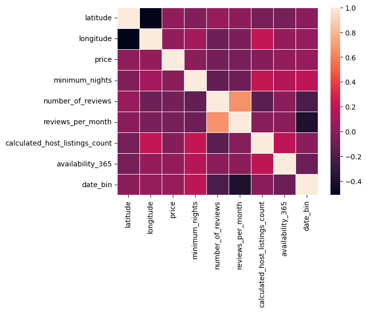

```python
sns.heatmap(airbnb_df.corr(), linewidth=.5)
```

As expected the number of reviews and the number of reviews per month has some corrlation, but not high enough for it to be removed. Price doesn't jump out to be correlated with any particular feature. I suspect location will be a big factor

To get a better look at the features lets remove a couple of the outliers on price. They will not be used in prediction or for testing (they are certainly out of my parents' budget as is). We will also remove free places

```python
airbnb_df2 = airbnb_df[airbnb_df['price'] < 2000]
df = airbnb_df2[airbnb_df2['price'] > 0]
```

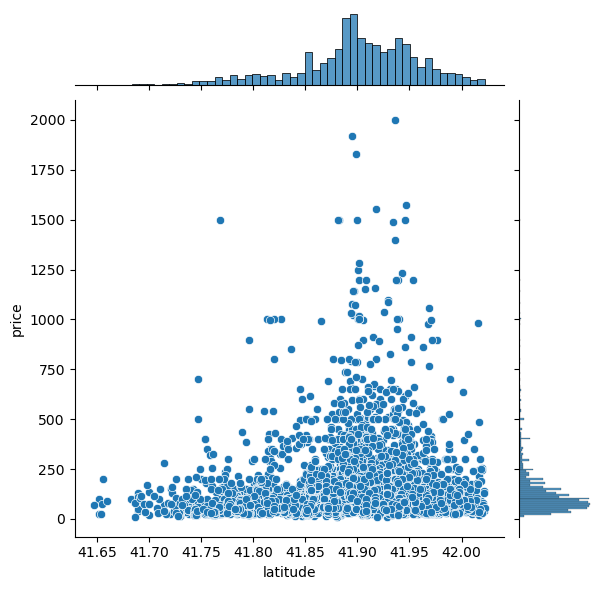

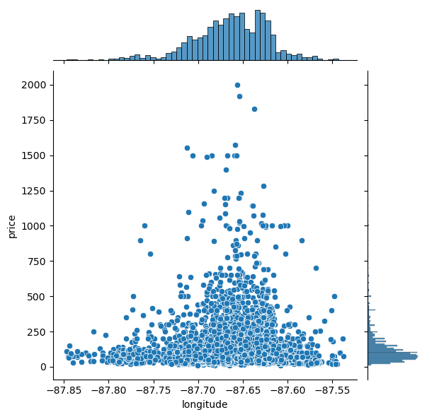

```python
# Let's see how location compares to price!
sns.jointplot(data=df, x='latitude', y='price')
sns.jointplot(data=df, x='longitude', y='price')
```

It looks like some of the highest pricest are located from 41.9-41.95 lat and -87.65 long, but it also looks like they have the most places to offer

I also suspect room_type should play in here... let's invesigate

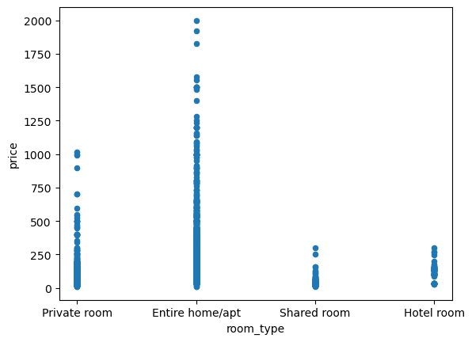

```python
df.plot(kind='scatter', x='room_type', y='price')
```

```python
df['room_type'].value_counts()
```

```
Entire home/apt    4392
Private room       1829
Shared room          90
Hotel room           69
Name: room_type, dtype: int64
```

Entire home/apt has the most options and variance in prices

For a bit more of processing - let's convert the room_type to numbers (one hot encoding). We'll repeat this with the neighborhood:

```python
df = pd.get_dummies(df, columns=['room_type', 'neighborhood'], drop_first=False)
```

```python
df.describe()
```

|  | latitude | longitude | price | minimum_nights | number_of_reviews | reviews_per_month | calculated_host_listings_count | availability_365 | date_bin | room_type_Entire home/apt | ... | neighborhood_Washington Heights | neighborhood_Washington Park | neighborhood_West Elsdon | neighborhood_West Englewood | neighborhood_West Garfield Park | neighborhood_West Lawn | neighborhood_West Pullman | neighborhood_West Ridge | neighborhood_West Town | neighborhood_Woodlawn |
| --- | --- | --- | --- | --- | --- | --- | --- | --- | --- | --- | --- | --- | --- | --- | --- | --- | --- | --- | --- | --- | --- |
| count | 6380.000000 | 6380.000000 | 6380.000000 | 6380.000000 | 6380.000000 | 6380.000000 | 6380.000000 | 6380.000000 | 6380.000000 | 6380.000000 | ... | 6380.000000 | 6380.000000 | 6380.000000 | 6380.000000 | 6380.000000 | 6380.000000 | 6380.000000 | 6380.000000 | 6380.000000 | 6380.000000 |
| mean | 41.899030 | -87.664067 | 137.948119 | 8.106740 | 42.841536 | 1.792019 | 13.622414 | 174.186520 | 9.318809 | 0.688401 | ... | 0.000940 | 0.005172 | 0.000313 | 0.000470 | 0.002194 | 0.001567 | 0.000313 | 0.010815 | 0.113166 | 0.013166 |
| std | 0.058979 | 0.042452 | 146.376317 | 22.794935 | 67.116230 | 1.587680 | 37.225335 | 138.883366 | 8.385835 | 0.463183 | ... | 0.030655 | 0.071739 | 0.017704 | 0.021681 | 0.046796 | 0.039562 | 0.017704 | 0.103440 | 0.316821 | 0.113995 |
| min | 41.647360 | -87.846810 | 10.000000 | 1.000000 | 0.000000 | 0.020000 | 1.000000 | 0.000000 | 3.000000 | 0.000000 | ... | 0.000000 | 0.000000 | 0.000000 | 0.000000 | 0.000000 | 0.000000 | 0.000000 | 0.000000 | 0.000000 | 0.000000 |
| 25% | 41.872610 | -87.687573 | 64.000000 | 1.000000 | 2.000000 | 0.570000 | 1.000000 | 35.750000 | 4.000000 | 0.000000 | ... | 0.000000 | 0.000000 | 0.000000 | 0.000000 | 0.000000 | 0.000000 | 0.000000 | 0.000000 | 0.000000 | 0.000000 |
| 50% | 41.901880 | -87.660895 | 99.000000 | 2.000000 | 15.000000 | 1.740000 | 2.000000 | 161.000000 | 9.000000 | 1.000000 | ... | 0.000000 | 0.000000 | 0.000000 | 0.000000 | 0.000000 | 0.000000 | 0.000000 | 0.000000 | 0.000000 | 0.000000 |
| 75% | 41.939782 | -87.633158 | 154.000000 | 3.000000 | 56.000000 | 2.220000 | 7.000000 | 329.000000 | 10.000000 | 1.000000 | ... | 0.000000 | 0.000000 | 0.000000 | 0.000000 | 0.000000 | 0.000000 | 0.000000 | 0.000000 | 0.000000 | 0.000000 |
| max | 42.022510 | -87.537520 | 1999.000000 | 500.000000 | 632.000000 | 32.430000 | 205.000000 | 365.000000 | 88.000000 | 1.000000 | ... | 1.000000 | 1.000000 | 1.000000 | 1.000000 | 1.000000 | 1.000000 | 1.000000 | 1.000000 | 1.000000 | 1.000000 |

8 rows × 90 columns

## Splitting the data

Split: 80% train, 10% val, 10% test

```python
y = df.price
X = df.drop('price', axis=1)

X_train, X_temp, y_train, y_temp = sklearn.model_selection.train_test_split(X, y, train_size=.8, random_state=0)
X_val, X_test, y_val, y_test = sklearn.model_selection.train_test_split(X_temp, y_temp, train_size=.5, random_state=0)
```

We will need to standardize the data... perhaps Z score, etc.

```python
ss = StandardScaler()
ss.fit(X_train)
X_train = ss.transform(X_train)
X_val = ss.transform(X_val)
X_test = ss.transform(X_test)
```

## Time to get down to business: Model Selection

We will use these three functions below (these were implemented in my Project 3 for this class)

```python
# fits model, makes predictions and displays results
def train_validate_model(model, X_train, X_val, y_train, y_val):
    model = model.fit(X_train, y_train)
    train_pred = model.predict(X_train)
    val_pred = model.predict(X_val)

    r2, rmse = get_metrics(y_train, train_pred)
    print_metrics("Train results", r2, rmse)
    r2, rmse = get_metrics(y_val, val_pred)
    print_metrics("Validation results", r2, rmse)
    return model
```

```python
 #displays metrics
def print_metrics(description, r2, rmse):
    print("{0}: R2  {1:.4f} RMSE: {2:.4f}".format(description, r2, rmse))
```

```python
# returns regression metrics
def get_metrics(true, pred):
    r2 = sklearn.metrics.r2_score(true, pred)
    mse = sklearn.metrics.mean_squared_error(true, pred)
    rmse = math.sqrt(mse)
    return r2, rmse
```

We'll use most of the models we went over in class and throw in a new one - a neural network.

```python
models = [LinearRegression(), RandomForestRegressor(), LogisticRegression(), SVR(kernel='rbf'), SVR(kernel='linear'), SVR(kernel='poly'), MLPRegressor(max_iter=500)]
for model in models:
    print('\n' + str(model))
    model = train_validate_model(model, X_train, X_val, y_train, y_val)
```

```
LinearRegression()
Train results: R2  0.1887 RMSE: 128.3588
Validation results: R2  -1208349934854503137280.0000 RMSE: 5689227036233.3818

RandomForestRegressor()
Train results: R2  0.8976 RMSE: 45.6088
Validation results: R2  0.3390 RMSE: 133.0612

LogisticRegression()
Train results: R2  -0.0252 RMSE: 144.2909
Validation results: R2  -0.1309 RMSE: 174.0476

SVR()
Train results: R2  0.0429 RMSE: 139.4168
Validation results: R2  0.0363 RMSE: 160.6672

SVR(kernel='linear')
Train results: R2  0.0864 RMSE: 136.2175
Validation results: R2  0.0697 RMSE: 157.8566

SVR(kernel='poly')
Train results: R2  -0.0275 RMSE: 144.4559
Validation results: R2  -0.0370 RMSE: 166.6649

MLPRegressor(max_iter=500)
Train results: R2  0.3403 RMSE: 115.7447
Validation results: R2  0.1636 RMSE: 149.6814
```

Something is going wrong with the linear regression. I suspect division by zero. Even by looking at the training data it is not a good fit though. The random forest is clearly overfitting and the MLP is clearly underfitting, but they look the best so far... let's check out a feature importance graph for the random forest.

```python
# Generates feature importance graph (excludes neighborhood one hot encoding)
def make_features_graph(X_train, model, feature_names):
    num_features = X_train.shape[1]
    array = np.arange(len(less_feat))
    plt.barh(y=array, width=list(model.feature_importances_[:len(less_feat)]), align='center')
    plt.yticks(array, less_feat)
    plt.title("Feature Importance Graph for Random Forest Model")
    plt.show()
```

```
Train results: R2  0.8922 RMSE: 46.7997
Validation results: R2  0.3308 RMSE: 133.8814
```

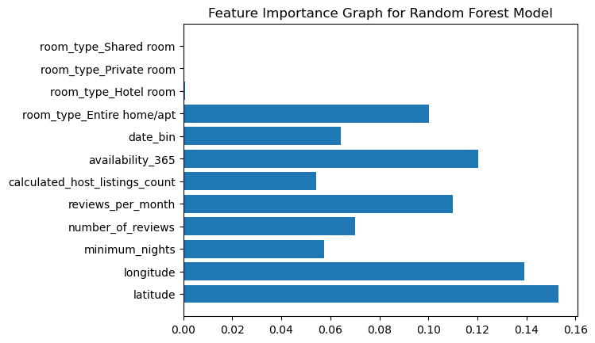

```python
# gathering features
model = RandomForestRegressor()
model = train_validate_model(model, X_train, X_val, y_train, y_val)
feature_names = list(df.columns)
less_feat = []
for feature in feature_names:
    if not feature.startswith('neighborhood') and not feature.startswith('price'):
        less_feat.append(feature)
make_features_graph(X_train, model, feature_names)
```

## Let's do it again with PCA

Let's try some PCA and see if we get similar results... what complicates this is the one hot enconding (adds many more features)

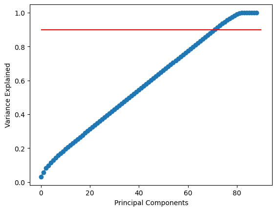

```python
pca = PCA(n_components=None)
pca.fit(X_train)
X_train_pca_unreduced = pca.transform(X_train)
X_val_pca_unreduced = pca.transform(X_val)
X_test_pca_unreduced = pca.transform(X_test)
plt.plot(pca.explained_variance_ratio_.cumsum(), '-o');
plt.xlabel('Principal Components')
plt.ylabel('Variance Explained')
plt.hlines(.9, xmin=0, xmax=90, color='red')
plt.show()
```

Looks like about 75 components gets us 90% of the variance (our thumb-rule)

```python
X_train_pca = X_train_pca_unreduced[:, 0:75]
X_val_pca = X_val_pca_unreduced[:, 0:75]
X_test_pca = X_test_pca_unreduced[:, 0:75]
```

Let's see the models now with PCA...

```python
models = [LinearRegression(), RandomForestRegressor(), LogisticRegression(), SVR(kernel='rbf'), SVR(kernel='linear'), SVR(kernel='poly'), MLPRegressor(max_iter=500)]
for model in models:
    print('\n' + str(model))
    train_validate_model(model, X_train_pca, X_val_pca, y_train, y_val)
```

```
LinearRegression()
Train results: R2  0.1554 RMSE: 130.9677
Validation results: R2  0.0737 RMSE: 157.5197

RandomForestRegressor()
Train results: R2  0.8878 RMSE: 47.7301
Validation results: R2  0.2083 RMSE: 145.6279

LogisticRegression()
Train results: R2  -0.0577 RMSE: 146.5618
Validation results: R2  -0.0685 RMSE: 169.1821

SVR()
Train results: R2  0.0375 RMSE: 139.8140
Validation results: R2  0.0310 RMSE: 161.1078

SVR(kernel='linear')
Train results: R2  0.0617 RMSE: 138.0455
Validation results: R2  -0.0428 RMSE: 167.1350

SVR(kernel='poly')
Train results: R2  -0.0283 RMSE: 144.5151
Validation results: R2  -0.0368 RMSE: 166.6466

MLPRegressor(max_iter=500)
Train results: R2  0.2784 RMSE: 121.0600
Validation results: R2  0.1466 RMSE: 151.1942
```

**We will choose random forest for the model!**

## Validation Curves and Hyperparameter tuning

Let's do some validation curves now and then get to grid search!

For the Random Forest:

```python
def plot_validation_curve(hyperparams, hyperparam_name, r2_train, r2_val):
    fig, ax = plt.subplots()
    plt.plot(hyperparams, r2_train, marker='o', color='green', label = 'train')
    plt.plot(hyperparams, r2_val, color='gold', marker='o', label = 'val')
    plt.title('Validation Curve for ' + hyperparam_name)
    plt.xlabel(hyperparam_name)
    plt.ylabel('r2')
    plt.legend()
    plt.show()
```

```python
# loops through various max_depths, fitting the model and making various predictions
def prep_for_validation_curve(hyperparams, hyperparam_name):
    r2_train = []
    r2_val = []
    for hyperparam in hyperparams:
        if hyperparam_name.startswith('n_'):
            model = RandomForestRegressor(n_estimators=hyperparam)
        elif hyperparam_name.startswith('max_depth'):
            model = RandomForestRegressor(max_depth=hyperparam)
        elif hyperparam_name.startswith('min_samples'):
            model = RandomForestRegressor(min_samples_split=hyperparam)
        model.fit(X_train, y_train)
        train_pred = model.predict(X_train)
        r2_train.append(sklearn.metrics.r2_score(y_true=y_train, y_pred=train_pred))
        val_pred = model.predict(X_val)
        r2_val.append(sklearn.metrics.r2_score(y_true=y_val, y_pred=val_pred))
    plot_validation_curve(hyperparams, hyperparam_name, r2_train, r2_val)
```

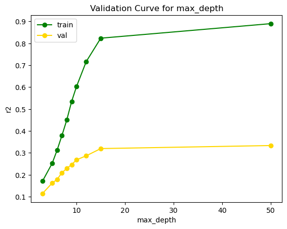

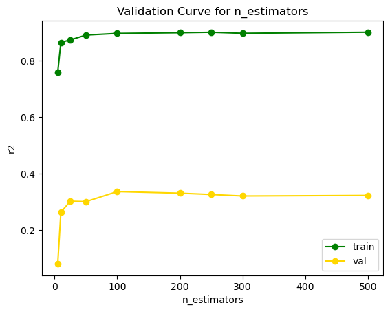

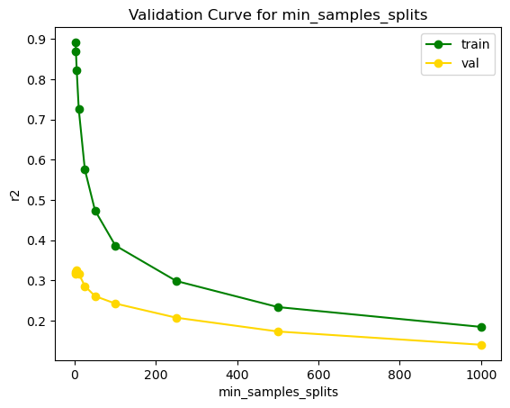

```python
# picking the various values for the hyperparams and running the model with them...
max_depths = [3, 5, 6, 7, 8, 9, 10, 12, 15, 50]
n_estimators = [5, 10, 25, 50, 100, 200, 250, 300, 500]
min_samples_splits = [2, 3, 5, 10, 25, 50, 100, 250, 500, 1000]
prep_for_validation_curve(max_depths, 'max_depth')
prep_for_validation_curve(n_estimators, 'n_estimators')
prep_for_validation_curve(min_samples_splits, 'min_samples_splits')
```

Let's do some grid search and hyperparameter tuning for random forest to see if we can get that r2 up! There are clear issues of overfitting... let's try to keep the model more simple (bigger numbers for min_splits, lower max_depth, fewer estimators). K-fold with k=2 will be used for time constraints (on run time).

```python
grid = sklearn.model_selection.GridSearchCV(estimator=RandomForestRegressor(), param_grid={"max_depth": [3, 5, 6, 7, 8, 9, 10, 12, 25, 100], "n_estimators": [5, 10, 25, 50, 100], "min_samples_split": [5, 25, 50, 100, 200]}, cv=2, scoring='r2', return_train_score=True)
grid.fit(X_train, y_train)
print("Best Hyperparams: ", grid.best_params_)
best_r2 = grid.best_score_
```

```
Best Hyperparams:  {'max_depth': 10, 'min_samples_split': 5, 'n_estimators': 100}
```

With the concern of overfitting I would like to see the training results too...

```python
results = pd.DataFrame(grid.cv_results_)
print(results.columns)
```

```
Index(['mean_fit_time', 'std_fit_time', 'mean_score_time', 'std_score_time',
       'param_max_depth', 'param_min_samples_split', 'param_n_estimators',
       'params', 'split0_test_score', 'split1_test_score', 'mean_test_score',
       'std_test_score', 'rank_test_score', 'split0_train_score',
       'split1_train_score', 'mean_train_score', 'std_train_score'],
      dtype='object')
```

Let's put a threshold on r2 (for the validation data) for which hyperparams combinations to look at more. Only consider models in top 98% of r2 scores

```python
results = results[results['mean_test_score'] > best_r2 * .98]
```

Preparing to make a bar graph of training results and test results

```python
scores = results[['mean_train_score', 'mean_test_score']]
scores = scores.rename(columns={"mean_test_score": "mean_val_score"})
params = results[['param_min_samples_split', 'param_n_estimators', 'param_max_depth']]
index = []
# just changing the index names for the bar graph
for ind in params.index:
    spec_model = "split: " + str(params['param_min_samples_split'][ind]) + ", n_est: " + str(params['param_n_estimators'][ind]) + ", depth: " + str(params['param_max_depth'][ind])
    index.append(spec_model)
indexed_scores = scores.set_axis(index)
```

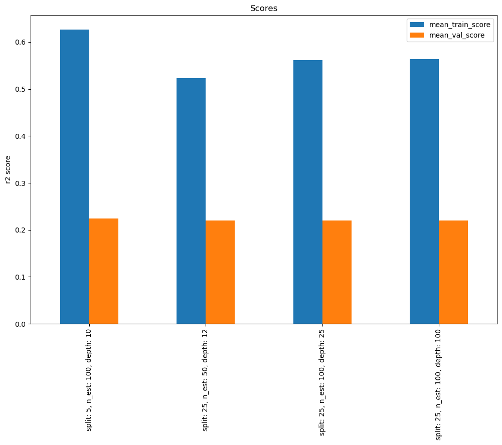

```python
indexed_scores.plot.bar(rot=90, ylabel='r2 score', title='Scores', figsize=(12, 8))
```

These models are all similar in their r2 scores...

Let's look at RMSE to break the ties!

```python
chosen_models = []
for ind in params.index:
    splits = params['param_min_samples_split'][ind]
    est = params['param_n_estimators'][ind]
    max_depth = params['param_max_depth'][ind]
    index = "split: " + str(splits) + ", n_est: " + str(est) + ", depth: " + str(max_depth)
    if index in indexed_scores.index:
        chosen_models.append(RandomForestRegressor(n_estimators=est, max_depth=max_depth, min_samples_split=splits))
```

```python
for model in chosen_models:
    print(str(model) + ":")
    train_validate_model(model, X_train, X_val, y_train, y_val)
    print('\n')
```

```
RandomForestRegressor(max_depth=10, min_samples_split=5):
Train results: R2  0.5644 RMSE: 94.0513
Validation results: R2  0.2616 RMSE: 140.6427


RandomForestRegressor(max_depth=12, min_samples_split=25, n_estimators=50):
Train results: R2  0.5023 RMSE: 100.5342
Validation results: R2  0.2702 RMSE: 139.8192


RandomForestRegressor(max_depth=25, min_samples_split=25):
Train results: R2  0.5747 RMSE: 92.9341
Validation results: R2  0.2946 RMSE: 137.4636


RandomForestRegressor(max_depth=100, min_samples_split=25):
Train results: R2  0.5790 RMSE: 92.4675
Validation results: R2  0.2831 RMSE: 138.5757
```

Due to overfitting we might not pick the one suggested by grid search... I will pick one where the training and test results are close-ish: **25 min sample splits, 25 for max depth and 100 estimators**

```python
max_depth = 25
splits = 25
est = 100
```

## Learning Curves

Let's plot the learning curve (with no PCA) for more information on how the training and validation is going.

```python
def plot_learning_curve(r2_train, r2_val, model_name, ns):
    fig, ax = plt.subplots()
    plt.plot(ns, r2_train, marker='o', color='green', label = 'train')
    plt.plot(ns, r2_val, marker='o', color='gold', label = 'validation')
    plt.title('Learning Curve for ' + model_name)
    plt.xlabel('Number of data points')
    plt.xticks(ns, rotation=90)
    plt.ylabel('r2')
    plt.legend()
    plt.show()
```

```python
def get_learning_curve_data(n, r2_train, r2_val, model):
    model.fit(X_train[0:n, :], y_train[0: n])
    train_pred = model.predict(X_train[0:n, :])
    r2_train.append(sklearn.metrics.r2_score(y_true=y_train[0:n], y_pred=train_pred))
    val_pred = model.predict(X_val)
    r2_val.append(sklearn.metrics.r2_score(y_true=y_val, y_pred=val_pred))
    return r2_train, r2_val
```

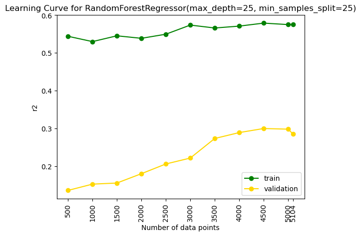

```
Peak validation results occurred when 4500 data points were used!
```

```python
chosen_models = [RandomForestRegressor(n_estimators=est, max_depth=max_depth, min_samples_split=splits)]
best_r2 = 0
best_n = 0
ns = []
for model in chosen_models:
    r2_train = []
    r2_val = []
    for n in range(500, X_train.shape[0], 500):
        ns.append(n)
        r2_train, r2_val = get_learning_curve_data(n, r2_train, r2_val, model)
        if r2_val[-1] > best_r2:
            best_r2 = r2_val[-1]
            best_n = n
    # now using all the data
    r2_train, r2_val = get_learning_curve_data(X_train.shape[0], r2_train, r2_val, model)
    if r2_val[-1] > best_r2:
            best_r2 = r2_val[-1]
            best_n = X_train.shape[0]
    model_name = str(model)
    ns.append(X_train.shape[0])
    plot_learning_curve(r2_train, r2_val, model_name, ns)
    print("Peak validation results occurred when {} data points were used!".format(best_n))
```

## One last time - train the model with the chosen hyperparams and then test!!

```python
# fits model, makes predictions and displays results
def train_test_model(model, X_train, X_test, y_train, y_test):
    model = model.fit(X_train, y_train)
    train_pred = model.predict(X_train)
    test_pred = model.predict(X_test)

    train_r2, train_rmse, train_mae, train_mape = get_metrics2(y_train, train_pred)
    print_metrics2("Train results", train_r2, train_rmse, train_mae, train_mape)
    test_r2, test_rmse, test_mae, test_mape = get_metrics2(y_test, test_pred)
    print_metrics2("Test results", test_r2, test_rmse, test_mae, test_mape)

    return model, [train_r2, test_r2], [train_rmse, test_rmse], [train_mae, test_mae], [train_mape, test_mape]

#displays metrics (rather than use the function way above in the code I will just add a 2 to the end)
def print_metrics2(description, r2, rmse, mae, mape):
    print("{0}: R2  {1:.4f} RMSE: {2:.4f} MAE: {3: .4f} MAPE: {4: .4f}".format(description, r2, rmse, mae, mape))

# returns regression metrics (rather than use the function way above in the code I will just add a 2 to the end)
def get_metrics2(true, pred):
    r2 = sklearn.metrics.r2_score(true, pred)
    mse = sklearn.metrics.mean_squared_error(true, pred)
    rmse = math.sqrt(mse)
    mae = sklearn.metrics.mean_absolute_error(true, pred)
    mape = sklearn.metrics.mean_absolute_percentage_error(true, pred)
    return r2, rmse, mae, mape
```

```python
model = RandomForestRegressor(max_depth=max_depth, min_samples_split=splits, n_estimators=est)
model, r2_res, rmse_res, mae_res, mape_res = train_test_model(model, X_train[:best_n], X_test, y_train[:best_n], y_test)
```

```
Train results: R2  0.5825 RMSE: 90.6376 MAE:  46.1667 MAPE:  0.3964
Test results: R2  0.2885 RMSE: 133.2585 MAE:  61.6292 MAPE:  0.5344
```

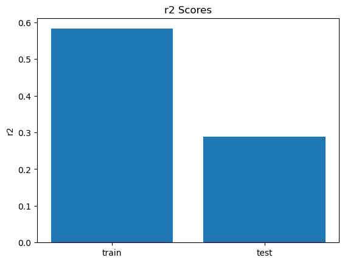

```python
plt.bar(x=[0, 1], height=r2_res, tick_label=['train', 'test'])
plt.ylabel("r2")
plt.title('r2 Scores')
```

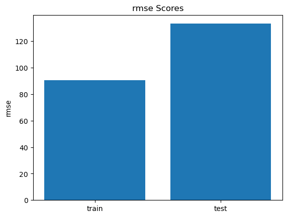

```python
plt.bar(x=[0, 1], height=rmse_res, tick_label=['train', 'test'])
plt.ylabel("rmse")
plt.title('rmse Scores')
```

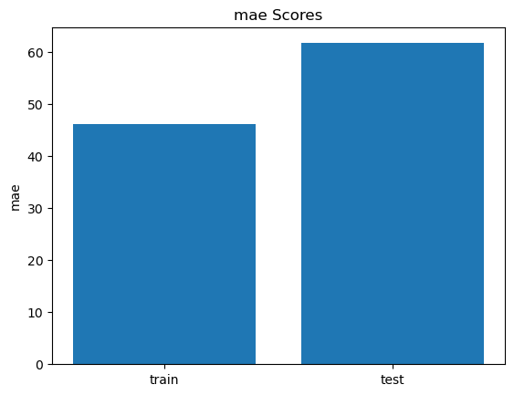

```python
plt.bar(x=[0, 1], height=mae_res, tick_label=['train', 'test'])
plt.ylabel("mae")
plt.title('mae Scores')
```

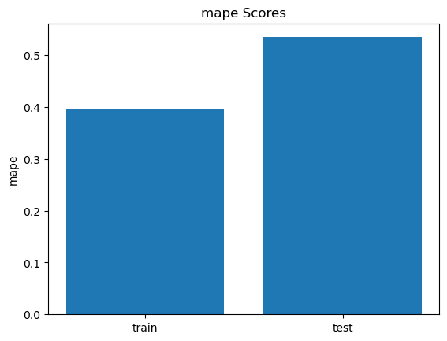

```python
plt.bar(x=[0, 1], height=mape_res, tick_label=['train', 'test'])
plt.ylabel("mape")
plt.title('mape Scores')
```

Overall I'm pretty pleased with these results... we won't be trading stocks with them, but an average of ~$60 (MAE) from the correct result sounds pretty good. Mind you this over 50 percent off the true price, but not too bad

# Prediction time - the final step!!

So my parents will be in town for a week July 4th. They ideally would like to stay in the loop and have their own apartment/ home. Let's describe what these features will look like (we'll look at our data again to generate my parent's criteria for what to predict for)

```python
df.head()
```

|  | latitude | longitude | price | minimum_nights | number_of_reviews | reviews_per_month | calculated_host_listings_count | availability_365 | date_bin | room_type_Entire home/apt | ... | neighborhood_Washington Heights | neighborhood_Washington Park | neighborhood_West Elsdon | neighborhood_West Englewood | neighborhood_West Garfield Park | neighborhood_West Lawn | neighborhood_West Pullman | neighborhood_West Ridge | neighborhood_West Town | neighborhood_Woodlawn |
| --- | --- | --- | --- | --- | --- | --- | --- | --- | --- | --- | --- | --- | --- | --- | --- | --- | --- | --- | --- | --- | --- |
| 0 | 41.78790 | -87.58780 | 60 | 2 | 178 | 2.56 | 1 | 353 | 12.0 | 0 | ... | 0 | 0 | 0 | 0 | 0 | 0 | 0 | 0 | 0 | 0 |
| 1 | 41.85495 | -87.69696 | 105 | 2 | 395 | 2.81 | 1 | 155 | 5.0 | 1 | ... | 0 | 0 | 0 | 0 | 0 | 0 | 0 | 0 | 0 | 0 |
| 2 | 41.90289 | -87.68182 | 60 | 2 | 384 | 2.81 | 1 | 321 | 9.0 | 1 | ... | 0 | 0 | 0 | 0 | 0 | 0 | 0 | 0 | 1 | 0 |
| 3 | 41.91769 | -87.63788 | 65 | 4 | 49 | 0.63 | 9 | 300 | 14.0 | 1 | ... | 0 | 0 | 0 | 0 | 0 | 0 | 0 | 0 | 0 | 0 |
| 4 | 41.79612 | -87.59261 | 21 | 1 | 44 | 0.61 | 5 | 168 | 10.0 | 0 | ... | 0 | 0 | 0 | 0 | 0 | 0 | 0 | 0 | 0 | 0 |

5 rows × 90 columns

```python
# My parents would like to stay in the loop area of town
loop_df = df[df['neighborhood_Loop'] == 1]
print(loop_df['latitude'].mean())
print(loop_df['longitude'].mean())
```

```
41.88024875338757
-87.62739108401082
```

```python
df.describe()
```

|  | latitude | longitude | price | minimum_nights | number_of_reviews | reviews_per_month | calculated_host_listings_count | availability_365 | date_bin | room_type_Entire home/apt | ... | neighborhood_Washington Heights | neighborhood_Washington Park | neighborhood_West Elsdon | neighborhood_West Englewood | neighborhood_West Garfield Park | neighborhood_West Lawn | neighborhood_West Pullman | neighborhood_West Ridge | neighborhood_West Town | neighborhood_Woodlawn |
| --- | --- | --- | --- | --- | --- | --- | --- | --- | --- | --- | --- | --- | --- | --- | --- | --- | --- | --- | --- | --- | --- |
| count | 6380.000000 | 6380.000000 | 6380.000000 | 6380.000000 | 6380.000000 | 6380.000000 | 6380.000000 | 6380.000000 | 6380.000000 | 6380.000000 | ... | 6380.000000 | 6380.000000 | 6380.000000 | 6380.000000 | 6380.000000 | 6380.000000 | 6380.000000 | 6380.000000 | 6380.000000 | 6380.000000 |
| mean | 41.899030 | -87.664067 | 137.948119 | 8.106740 | 42.841536 | 1.792019 | 13.622414 | 174.186520 | 9.318809 | 0.688401 | ... | 0.000940 | 0.005172 | 0.000313 | 0.000470 | 0.002194 | 0.001567 | 0.000313 | 0.010815 | 0.113166 | 0.013166 |
| std | 0.058979 | 0.042452 | 146.376317 | 22.794935 | 67.116230 | 1.587680 | 37.225335 | 138.883366 | 8.385835 | 0.463183 | ... | 0.030655 | 0.071739 | 0.017704 | 0.021681 | 0.046796 | 0.039562 | 0.017704 | 0.103440 | 0.316821 | 0.113995 |
| min | 41.647360 | -87.846810 | 10.000000 | 1.000000 | 0.000000 | 0.020000 | 1.000000 | 0.000000 | 3.000000 | 0.000000 | ... | 0.000000 | 0.000000 | 0.000000 | 0.000000 | 0.000000 | 0.000000 | 0.000000 | 0.000000 | 0.000000 | 0.000000 |
| 25% | 41.872610 | -87.687573 | 64.000000 | 1.000000 | 2.000000 | 0.570000 | 1.000000 | 35.750000 | 4.000000 | 0.000000 | ... | 0.000000 | 0.000000 | 0.000000 | 0.000000 | 0.000000 | 0.000000 | 0.000000 | 0.000000 | 0.000000 | 0.000000 |
| 50% | 41.901880 | -87.660895 | 99.000000 | 2.000000 | 15.000000 | 1.740000 | 2.000000 | 161.000000 | 9.000000 | 1.000000 | ... | 0.000000 | 0.000000 | 0.000000 | 0.000000 | 0.000000 | 0.000000 | 0.000000 | 0.000000 | 0.000000 | 0.000000 |
| 75% | 41.939782 | -87.633158 | 154.000000 | 3.000000 | 56.000000 | 2.220000 | 7.000000 | 329.000000 | 10.000000 | 1.000000 | ... | 0.000000 | 0.000000 | 0.000000 | 0.000000 | 0.000000 | 0.000000 | 0.000000 | 0.000000 | 0.000000 | 0.000000 |
| max | 42.022510 | -87.537520 | 1999.000000 | 500.000000 | 632.000000 | 32.430000 | 205.000000 | 365.000000 | 88.000000 | 1.000000 | ... | 1.000000 | 1.000000 | 1.000000 | 1.000000 | 1.000000 | 1.000000 | 1.000000 | 1.000000 | 1.000000 | 1.000000 |

8 rows × 90 columns

Where my parents will be staying: Latitude: 41.88 (average for the loop) Longitude: -87.63 (average for the loop) min_nights: 1 (they wouldn't want a minimum number of nights) num_reviews: 43 (average) reviews_per_month: 2 (average) calc_host_listings: 13 (average) availability: 174 (average) date_bin: 9 (average)

for the one hot encoding features: room_entire_apt: 1 (their own place to stay) neighborhood_Loop: 1 (near where I live)

```python
df.columns
```

```
Index(['latitude', 'longitude', 'price', 'minimum_nights', 'number_of_reviews',
       'reviews_per_month', 'calculated_host_listings_count',
       'availability_365', 'date_bin', 'room_type_Entire home/apt',
       'room_type_Hotel room', 'room_type_Private room',
       'room_type_Shared room', 'neighborhood_Albany Park',
       'neighborhood_Archer Heights', 'neighborhood_Armour Square',
       'neighborhood_Ashburn', 'neighborhood_Auburn Gresham',
       'neighborhood_Austin', 'neighborhood_Avalon Park',
       'neighborhood_Avondale', 'neighborhood_Belmont Cragin',
       'neighborhood_Beverly', 'neighborhood_Bridgeport',
       'neighborhood_Brighton Park', 'neighborhood_Burnside',
       'neighborhood_Calumet Heights', 'neighborhood_Chatham',
       'neighborhood_Chicago Lawn', 'neighborhood_Clearing',
       'neighborhood_Douglas', 'neighborhood_Dunning',
       'neighborhood_East Garfield Park', 'neighborhood_East Side',
       'neighborhood_Edgewater', 'neighborhood_Edison Park',
       'neighborhood_Englewood', 'neighborhood_Forest Glen',
       'neighborhood_Fuller Park', 'neighborhood_Gage Park',
       'neighborhood_Garfield Ridge', 'neighborhood_Grand Boulevard',
       'neighborhood_Greater Grand Crossing', 'neighborhood_Hegewisch',
       'neighborhood_Hermosa', 'neighborhood_Humboldt Park',
       'neighborhood_Hyde Park', 'neighborhood_Irving Park',
       'neighborhood_Jefferson Park', 'neighborhood_Kenwood',
       'neighborhood_Lake View', 'neighborhood_Lincoln Park',
       'neighborhood_Lincoln Square', 'neighborhood_Logan Square',
       'neighborhood_Loop', 'neighborhood_Lower West Side',
       'neighborhood_Mckinley Park', 'neighborhood_Montclare',
       'neighborhood_Morgan Park', 'neighborhood_Mount Greenwood',
       'neighborhood_Near North Side', 'neighborhood_Near South Side',
       'neighborhood_Near West Side', 'neighborhood_New City',
       'neighborhood_North Center', 'neighborhood_North Lawndale',
       'neighborhood_North Park', 'neighborhood_Norwood Park',
       'neighborhood_Oakland', 'neighborhood_Ohare',
       'neighborhood_Portage Park', 'neighborhood_Pullman',
       'neighborhood_Riverdale', 'neighborhood_Rogers Park',
       'neighborhood_Roseland', 'neighborhood_South Chicago',
       'neighborhood_South Deering', 'neighborhood_South Lawndale',
       'neighborhood_South Shore', 'neighborhood_Uptown',
       'neighborhood_Washington Heights', 'neighborhood_Washington Park',
       'neighborhood_West Elsdon', 'neighborhood_West Englewood',
       'neighborhood_West Garfield Park', 'neighborhood_West Lawn',
       'neighborhood_West Pullman', 'neighborhood_West Ridge',
       'neighborhood_West Town', 'neighborhood_Woodlawn'],
      dtype='object')
```

```python
# making the input for the predictor
one_hots_for_neighborhood = []
for col in list(df.columns):
    if col.startswith('neighborhood'):
        if col == 'neighborhood_Loop':
            one_hots_for_neighborhood.append(1)
        else:
            one_hots_for_neighborhood.append(0)
```

```python
to_predict = [41.88, -87.63, 1, 43, 2, 13, 174, 9, 1, 0, 0, 0] + one_hots_for_neighborhood
to_predict = np.array(to_predict)
to_predict = to_predict.reshape(1, -1)
print(to_predict.shape)
```

```
(1, 89)
```

```python
old_pred = round(model.predict(to_predict)[0], 2)
print(old_pred)
```

```
123.88
```

**Wow that's low!**

We know the data was taken from a few years ago (the latest reviews were done in late 2020) - we will assume it is an average of 3-4 years old (2019). Using this source https://ipropertymanagement.com/research/average-rent-increase-per-year from 2019 to 2020 rent increased on average (we'll assume airbnb prices in Chicago match this) by 3%, from 2020 to 2021 2%, from 2021 to 2022 2% and finally we'll assume another 1% by mid July this year

```python
increases = [1.03, 1.02, 1.02, 1.01]
for increase in increases:
    old_pred *= increase
final_pred = old_pred
print(round(final_pred, 2))
```

```
134.08
```

This looks very low!! Especially for holidays! Perhaps the model is quite low and also the price increases in airbnb are much greater than the renting... especially for July 4th weekend (they've told me they are finding prices in the high $200's at the low end)

One thing that this data does not capture is time. An airbnb around July 4th will be substantially higher than in the frigid Chicago winters. Having some sort of time feature would be benficial for a more thorough analysis.

If I had more time I would do further analysis of the MLP model and also try to get additional time-based data and more recent data. I would look at feature crosses and potentially removing some features.

Overall although my prediction is certainly lower than market data, I think the project was succesful in modeling the data. I learned a lot by completing this project and thoroughly enjoyed it!